# Project 3 - Dataset 1 - MTA Ridership

Author

Amanda Fox

Published

February 29, 2024

### Background

In this project, Anna Moy presented us with a dataset of ridership statistics from the MTA for tidying and analysis (https://data.ny.gov/Transportation/MTA-Daily-Ridership-Data-Beginning-2020/vxuj-8kew/data_preview).

She asked us to compare average daily ridership by year and mode of transportation and answer the following questions:

1. Summarize the 2020, 2021, 2022 average ridership for Subway, Buses, LIRR and Metro-North.
2. Compare the Subway and Buses and determine did more people take the Subway or Bus in 2020.
3. Which transportation has the highest and lowest ridership in 2020.

I began by loading the libraries:

```r
# -------- Load libraries

library(tidyverse)
library(ggplot2)
library(scales)
library(RColorBrewer)
```

#### Cleaning and Tidying

Then I loaded the data to a data frame and did some minimal cleaning and tidying: removed extra columns, unpivoted the columns, and used stringr to extract the year from a date field which was stored as character:

```r
# -------- Load datafile as dataframe df_mta

df_mta <- read_csv("https://raw.githubusercontent.com/AmandaSFox/DATA607/main/project_2/Dataset_1_MTA/MTA_Daily_Ridership_Data__Beginning_2020_20240228.csv")
# -------- Select out columns of interest, change names, and check data types

df_mta_slim <- df_mta %>%
  select(`Date`,`Subways: Total Estimated Ridership`,`Buses: Total Estimated Ridership`,
         `LIRR: Total Estimated Ridership`,`Metro-North: Total Estimated Ridership`) %>%
  dplyr::rename(`date`=`Date`, `Subway` = `Subways: Total Estimated Ridership`, `Bus` = `Buses: Total Estimated Ridership`,
                `LIRR` = `LIRR: Total Estimated Ridership`, `Metro-North` = `Metro-North: Total Estimated Ridership`)

str(df_mta_slim)
```

```
tibble [1,459 × 5] (S3: tbl_df/tbl/data.frame)
 $ date       : chr [1:1459] "3/1/2020" "3/2/2020" "3/3/2020" "3/4/2020" ...
 $ Subway     : num [1:1459] 2212965 5329915 5481103 5498809 5496453 ...
 $ Bus        : num [1:1459] 984908 2209066 2228608 2177165 2244515 ...
 $ LIRR       : num [1:1459] NA 321569 319727 311662 307597 ...
 $ Metro-North: num [1:1459] 55826 180702 190648 192689 194387 ...
```

```r
# -------- Extract four digit year as string from char field "date"

df_mta_slim <- df_mta_slim %>%
  mutate(`year` = str_sub(df_mta$Date, start = -4))

# -------- Melt modes of transportation

df_mta_melt <- df_mta_slim %>%
  pivot_longer(cols = c("Subway","Bus","LIRR","Metro-North"),
             names_to = "mode",
             values_to = "riders")

head(df_mta_melt)
```

```
# A tibble: 6 × 4
  date     year  mode         riders
  <chr>    <chr> <chr>         <dbl>
1 3/1/2020 2020  Subway      2212965
2 3/1/2020 2020  Bus          984908
3 3/1/2020 2020  LIRR             NA
4 3/1/2020 2020  Metro-North   55826
5 3/2/2020 2020  Subway      5329915
6 3/2/2020 2020  Bus         2209066
```

#### Finding the means and generating a plot

With the data prepared, it was easy to calculate the mean ridership and create a bar chart to answer the questions:

1. Summarize the 2020, 2021, 2022 average ridership for Subway, Buses, LIRR and Metro-North. **See Below**
2. Compare the Subway and Buses and determine did more people take the Subway or Bus in 2020. **Subway**
3. Which transportation has the highest and lowest ridership in 2020. **Subways had the highest daily ridership and Metro-North the lowest in all years**

```r
# -------- Calculate mean ridership by year 2020-22

df_years <- c("2020","2021","2022")

df_final <- df_mta_melt %>%
  filter(`year` %in% df_years) %>%
  group_by(`year`, mode) %>%
  summarize (mean_ridership = round(mean(riders, na.rm = TRUE)))
df_disp <- df_final %>%
  pivot_wider(names_from = mode, values_from = mean_ridership)

df_disp
```

```
# A tibble: 3 × 5
# Groups:   year [3]
  year      Bus   LIRR `Metro-North`  Subway
  <chr>   <dbl>  <dbl>         <dbl>   <dbl>
1 2020   481659  58131         37545 1209467
2 2021  1045583  96630         72498 2081672
3 2022  1161498 142462        126138 2773989
```

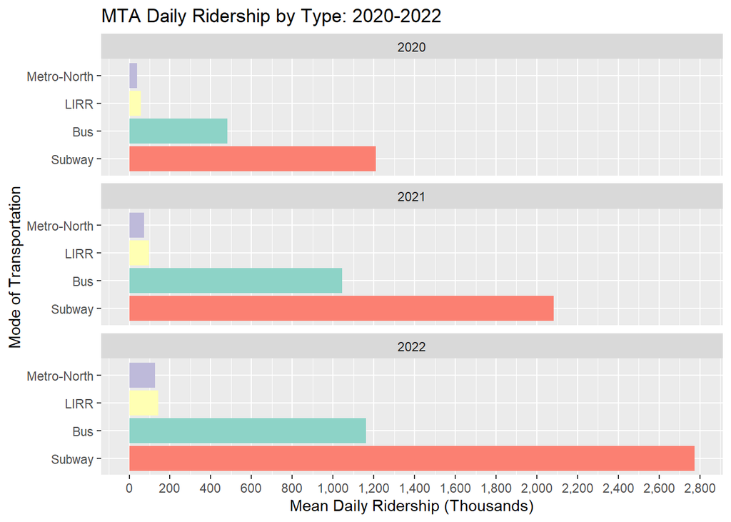

```r
# -------- Create bar chart

ggplot(df_final,aes(x=reorder(`mode`,-mean_ridership),
                    y = mean_ridership/1000,
                    fill = mode)) +
  geom_bar(stat = "identity") +
  scale_fill_brewer(palette = "Set3") +
  scale_y_continuous(n.breaks=20, labels = scales::label_comma()) +
  coord_flip() +
  facet_wrap(~`year`,nrow = 3) +
  xlab("Mode of Transportation") +
  ylab("Mean Daily Ridership (Thousands)") +
  theme(legend.position = "") +
  ggtitle("MTA Daily Ridership by Type: 2020-2022")
```